# wnba

**1. Define a Problem:**

I love the WNBA! There is a lot of analysis done on the men's game, but the women's game deserves as much attention. I want to predict which team statistics(shooting percentages, rebounds, turnovers etc.) most strongly influence winning in the WNBA and find out the key predictors of winning. I also want to explore whether certain teams rely more on offense/defense to win games.

**2. Determine the population:**

The population is box score statistics from WNBA games played over several seasons. The box score statistics usually includes Team name, opponent, points, rebounds, turnovers and other performance metrics. Each game is treated as a single observation

**3.Identify Variable(s)**

i) Independent Variables: Points, Turnovers, Rebounds, Steals, Blocks, Field goals, 3 Pointers, Free throws, Personal Fouls.

ii) Dependent Variable: Game outcome (Win/Loss)

iii) Confounder Variable: Player availablity due to injuries and roster changes (missing of an important player), and Inconsistency in game officiating (increase in free throws etc.) can affect game outcomes.

**4. Formulate a Hypothesis:**

If a team's shooting efficiency (field goal percentage or three point percentage) increases, then the team tends to score more points and win more games.

**5. Develop a detailed plan for data collection**

To ensure representativeness when using a sample, I will include data from multiple seasons rather than just a single year. I will ensure all WNBA teams are represented in the sample which helps avoid bias towards a particular team.

**6. Choose a Dataset:**

I find this dataset interesting because it provides a comprehensive view of the wnba games including the game information, team performance stats for both the teams and advanced game metrics. This dataset contains:

1. Season - the year in which the game was played
2. Team - Name of the team whose stats are reported
3. G# - game number for that team
4. Date
5. Home - if it is a home game (1) or away game (0)
6. Opp - Opponent team
7. W/L - Win or Loss

Team performance stats:

1. Tm_pts - points scored by the team
2. Tm_FG - Field goals (any shot other than a free throw) made by the team
3. Tm_FGA - Field goals attempted by the team
4. Tm_FG% - Field goal percentage
5. Tm_3P - Three point Field goals made by the team
6. Tm_3PA - Three point Field goals attempted by the team
7. Tm_3PA% - Three point percentage
8. Tm_FT - Free throws made
9. Tm_FTA - Free throws attempted
10. Tm_FT% - Free throw percentage
11. Tm_ORB - Offensive Rebounds
12. Tm_TRB - Total Rebounds
13. Tm_AST - Assists
14. Tm_STL - Steals
15. Tm_BLK - blocks
16. Tm_TOV - turnovers
17. Tm_PF - Personal fouls committed

Opponent Stats:

1. Opp_pts - points scored by the opponent
2. Opp_FG - Field goals (any shot other than a free throw) made by the opponent
3. Opp_FGA - Field goals attempted by the opponent
4. Opp_FG% - Field goal percentage
5. Opp_3P - Three point Field goals made by the opponent
6. Opp_3PA - Three point Field goals attempted by the opponent
7. Opp_3PA% - Three point percentage
8. Opp_FT - Free throws made
9. Opp_FTA - Free throws attempted
10. Opp_FT% - Free throw percentage
11. Opp_ORB - Offensive Rebounds
12. Opp_TRB - Total Rebounds
13. Opp_AST - Assists
14. Opp_STL - Steals
15. Opp_BLK - blocks
16. Opp_TOV - turnovers
17. Opp_PF - Personal fouls committed

Advanced Game Metrics:

1. win_margin - the difference in the points scored (Tm_pts - Opp_pts)
2. Tm_poss - Estimated possessions by the team
3. Opp_poss - Estimated possessions by the opponent
4. Tm_off_rating - offensive rating (points per 100 possession by the team)
5. Tm_def_rating - defensive rating (points allowed per 100 possession by the team)
6. Tm_tov_rate - Team turnover rate (turnovers per possession)
7. Opp_tov_rate - Opponent turnover rate (turnovers per possession)

I downloaded this dataset from kaggle (Link: https://www.kaggle.com/datasets/natoshakennebrew/wnba-gamelogs-2015-2024) and will be using the file "wnba_gamelogs_2015_2025.csv" for this project. This dataset covers regular season gamelogs from 2015 to 2025.

From 2015 - 2024, the WNBA had 12 teams and in 2025, the league expanded to 13 teams. During the seasons 2015 - 2019, each team played 34 regular season games and in 2020, they played 22 games. In 2021, teams played 32 games and followed by an increase to 36 games in 2022. The schedule expanded to 40 games per team in 2023 and 2024 and in 2025, each team played 44.

```python
import pandas as pd
df = pd.read_csv('wnba_gamelogs_2015_2025.csv')
df.head()
```

|  | Season | Team | G# | Date | Home | Opp | W/L | Tm_Pts | Opp_Pts | Tm_FG | ... | Opp_BLK | Opp_TOV | Opp_PF | win_margin | Tm_poss | Opp_poss | Tm_off_rating | Tm_def_rating | Tm_tov_rate | Opp_tov_rate |
| --- | --- | --- | --- | --- | --- | --- | --- | --- | --- | --- | --- | --- | --- | --- | --- | --- | --- | --- | --- | --- | --- |
| 0 | 2015 | ATL | 1 | 2015-06-05 | 0 | NYL | L | 73 | 82 | 24 | ... | 4 | 15 | 20 | -9 | 83.68 | 82.44 | 87.237094 | 99.466279 | 0.227055 | 1.0 |
| 1 | 2015 | ATL | 2 | 2015-06-07 | 1 | CON | L | 70 | 75 | 25 | ... | 3 | 11 | 24 | -5 | 83.92 | 82.36 | 83.412774 | 91.063623 | 0.297903 | 1.0 |
| 2 | 2015 | ATL | 3 | 2015-06-11 | 1 | SAS | W | 72 | 69 | 28 | ... | 7 | 17 | 18 | 3 | 78.92 | 78.92 | 91.231627 | 87.430309 | 0.190066 | 1.0 |
| 3 | 2015 | ATL | 4 | 2015-06-12 | 0 | WAS | W | 64 | 61 | 24 | ... | 2 | 15 | 18 | 3 | 74.40 | 72.28 | 86.021505 | 84.394023 | 0.215054 | 1.0 |
| 4 | 2015 | ATL | 5 | 2015-06-14 | 0 | CON | L | 64 | 82 | 26 | ... | 0 | 23 | 16 | -18 | 83.28 | 78.64 | 76.849183 | 104.272635 | 0.288184 | 1.0 |

5 rows × 48 columns

```python
df.columns
```

```
Index(['Season', 'Team', 'G#', 'Date', 'Home', 'Opp', 'W/L', 'Tm_Pts',
       'Opp_Pts', 'Tm_FG', 'Tm_FGA', 'Tm_FG%', 'Tm_3P', 'Tm_3PA', 'Tm_3P%',
       'Tm_FT', 'Tm_FTA', 'Tm_FT%', 'Tm_ORB', 'Tm_TRB', 'Tm_AST', 'Tm_STL',
       'Tm_BLK', 'Tm_TOV', 'Tm_PF', 'Opp_FG', 'Opp_FGA', 'Opp_FG%', 'Opp_3P',
       'Opp_3PA', 'Opp_3P%', 'Opp_FT', 'Opp_FTA', 'Opp_FT%', 'Opp_ORB',
       'Opp_TRB', 'Opp_AST', 'Opp_STL', 'Opp_BLK', 'Opp_TOV', 'Opp_PF',
       'win_margin', 'Tm_poss', 'Opp_poss', 'Tm_off_rating', 'Tm_def_rating',
       'Tm_tov_rate', 'Opp_tov_rate'],
      dtype='object')
```

```python
from google.colab import drive
drive.mount('/content/drive')
```

```python
import pandas as pd
df = pd.read_csv('/content/drive/My Drive/wnba_gamelogs_2015_2025.csv')
df.head()
```

Drive Link: https://drive.google.com/file/d/1_Qj-jdKKXUnDKf5r0AR--qlgTlp5VJ2S/view?usp=sharing

**1 . Preliminary Information about the dataset**

```python
# shape of the dataset
df.shape
```

```
(4512, 48)
```

```python
# check for the names of the teams
print(df['Team'].unique())
print(df['Team'].nunique())
```

```
['ATL' 'CHI' 'CON' 'IND' 'LAS' 'MIN' 'NYL' 'PHO' 'SEA' 'WAS' 'DAL' 'LVA'
 'GSV']
13
```

```python
# check for the names of the opposition team
print(df['Opp'].unique())
print(df['Opp'].nunique())
# SAS and TUL are additional teams - check for this is this an issue?
```

```
['NYL' 'CON' 'SAS' 'WAS' 'IND' 'CHI' 'SEA' 'TUL' 'PHO' 'LAS' 'MIN' 'ATL'
 'DAL' 'LVA' 'GSV']
15
```

'Team' contains all the teams that are currently active in the league. While, 'Opponent' contains teams such as 'TUL' and 'SAS' that are no longer present in the league

```python
# General info
df.info()
```

```
<class 'pandas.core.frame.DataFrame'>
RangeIndex: 4512 entries, 0 to 4511
Data columns (total 48 columns):
 #   Column         Non-Null Count  Dtype
---  ------         --------------  -----
 0   Season         4512 non-null   int64
 1   Team           4512 non-null   object
 2   G#             4512 non-null   int64
 3   Date           4512 non-null   object
 4   Home           4512 non-null   int64
 5   Opp            4512 non-null   object
 6   W/L            4512 non-null   object
 7   Tm_Pts         4512 non-null   int64
 8   Opp_Pts        4512 non-null   int64
 9   Tm_FG          4512 non-null   int64
```

[output cut: 40 more lines]

```python
# Data types in the data
df.dtypes
```

|  | 0 |
| --- | --- |
| Season | int64 |
| Team | object |
| G# | int64 |
| Date | object |
| Home | int64 |
| Opp | object |
| W/L | object |
| Tm_Pts | int64 |
| Opp_Pts | int64 |
| Tm_FG | int64 |
| Tm_FGA | int64 |
| Tm_FG% | float64 |
| Tm_3P | int64 |
| Tm_3PA | int64 |
| Tm_3P% | float64 |
| Tm_FT | int64 |
| Tm_FTA | int64 |
| Tm_FT% | float64 |
| Tm_ORB | int64 |
| Tm_TRB | int64 |
| Tm_AST | int64 |
| Tm_STL | int64 |
| Tm_BLK | int64 |
| Tm_TOV | int64 |
| Tm_PF | int64 |
| Opp_FG | int64 |
| Opp_FGA | int64 |
| Opp_FG% | float64 |
| Opp_3P | int64 |
| Opp_3PA | int64 |
| Opp_3P% | float64 |
| Opp_FT | int64 |
| Opp_FTA | int64 |
| Opp_FT% | float64 |
| Opp_ORB | int64 |
| Opp_TRB | int64 |
| Opp_AST | int64 |
| Opp_STL | int64 |
| Opp_BLK | int64 |
| Opp_TOV | int64 |
| Opp_PF | int64 |
| win_margin | int64 |
| Tm_poss | float64 |
| Opp_poss | float64 |
| Tm_off_rating | float64 |
| Tm_def_rating | float64 |
| Tm_tov_rate | float64 |
| Opp_tov_rate | float64 |

**dtype:** object

```python
# all the columns/ variables in the data
all_columns = df.columns
print(all_columns)
```

```
Index(['Season', 'Team', 'G#', 'Date', 'Home', 'Opp', 'W/L', 'Tm_Pts',
       'Opp_Pts', 'Tm_FG', 'Tm_FGA', 'Tm_FG%', 'Tm_3P', 'Tm_3PA', 'Tm_3P%',
       'Tm_FT', 'Tm_FTA', 'Tm_FT%', 'Tm_ORB', 'Tm_TRB', 'Tm_AST', 'Tm_STL',
       'Tm_BLK', 'Tm_TOV', 'Tm_PF', 'Opp_FG', 'Opp_FGA', 'Opp_FG%', 'Opp_3P',
       'Opp_3PA', 'Opp_3P%', 'Opp_FT', 'Opp_FTA', 'Opp_FT%', 'Opp_ORB',
       'Opp_TRB', 'Opp_AST', 'Opp_STL', 'Opp_BLK', 'Opp_TOV', 'Opp_PF',
       'win_margin', 'Tm_poss', 'Opp_poss', 'Tm_off_rating', 'Tm_def_rating',
       'Tm_tov_rate', 'Opp_tov_rate'],
      dtype='object')
```

```python
# unique elements are in the data
df.nunique()
```

|  | 0 |
| --- | --- |
| Season | 11 |
| Team | 13 |
| G# | 44 |
| Date | 864 |
| Home | 2 |
| Opp | 15 |
| W/L | 2 |
| Tm_Pts | 73 |
| Opp_Pts | 73 |
| Tm_FG | 32 |
| Tm_FGA | 53 |
| Tm_FG% | 311 |
| Tm_3P | 21 |
| Tm_3PA | 41 |
| Tm_3P% | 222 |
| Tm_FT | 39 |
| Tm_FTA | 47 |
| Tm_FT% | 203 |
| Tm_ORB | 23 |
| Tm_TRB | 43 |
| Tm_AST | 31 |
| Tm_STL | 21 |
| Tm_BLK | 15 |
| Tm_TOV | 29 |
| Tm_PF | 30 |
| Opp_FG | 32 |
| Opp_FGA | 53 |
| Opp_FG% | 309 |
| Opp_3P | 21 |
| Opp_3PA | 41 |
| Opp_3P% | 222 |
| Opp_FT | 39 |
| Opp_FTA | 47 |
| Opp_FT% | 200 |
| Opp_ORB | 24 |
| Opp_TRB | 43 |
| Opp_AST | 31 |
| Opp_STL | 21 |
| Opp_BLK | 15 |
| Opp_TOV | 29 |
| Opp_PF | 30 |
| win_margin | 92 |
| Tm_poss | 664 |
| Opp_poss | 660 |
| Tm_off_rating | 3804 |
| Tm_def_rating | 3797 |
| Tm_tov_rate | 2940 |
| Opp_tov_rate | 1 |

**dtype:** int64

```python
# descriptive statistics
df.describe()
```

|  | Season | G# | Home | Tm_Pts | Opp_Pts | Tm_FG | Tm_FGA | Tm_FG% | Tm_3P | Tm_3PA | ... | Opp_BLK | Opp_TOV | Opp_PF | win_margin | Tm_poss | Opp_poss | Tm_off_rating | Tm_def_rating | Tm_tov_rate | Opp_tov_rate |
| --- | --- | --- | --- | --- | --- | --- | --- | --- | --- | --- | --- | --- | --- | --- | --- | --- | --- | --- | --- | --- | --- |
| count | 4512.000000 | 4512.000000 | 4512.000000 | 4512.000000 | 4512.000000 | 4512.000000 | 4512.000000 | 4512.000000 | 4512.000000 | 4512.000000 | ... | 4512.000000 | 4512.000000 | 4512.000000 | 4512.000000 | 4512.000000 | 4512.000000 | 4512.000000 | 4512.000000 | 4512.000000 | 4512.0 |
| mean | 2020.427305 | 18.423759 | 0.500000 | 81.346410 | 81.171764 | 29.809397 | 67.927748 | 0.439962 | 6.989805 | 20.506871 | ... | 3.927305 | 13.162234 | 17.989362 | 0.174645 | 80.721986 | 80.729548 | 100.843126 | 100.605123 | 0.162692 | 1.0 |
| std | 3.243880 | 10.759825 | 0.500055 | 11.221906 | 11.329019 | 4.658121 | 6.380259 | 0.063563 | 3.107885 | 6.271190 | ... | 2.257142 | 3.812475 | 4.124463 | 13.968505 | 5.051364 | 5.046140 | 13.017683 | 13.080971 | 0.045253 | 0.0 |
| min | 2015.000000 | 1.000000 | 0.000000 | 45.000000 | 45.000000 | 15.000000 | 43.000000 | 0.234000 | 0.000000 | 3.000000 | ... | 0.000000 | 1.000000 | 6.000000 | -59.000000 | 64.080000 | 64.080000 | 56.053812 | 57.829181 | 0.013904 | 1.0 |
| 25% | 2018.000000 | 9.000000 | 0.000000 | 74.000000 | 74.000000 | 27.000000 | 64.000000 | 0.397000 | 5.000000 | 16.000000 | ... | 2.000000 | 10.000000 | 15.000000 | -9.000000 | 77.400000 | 77.430000 | 91.846316 | 91.627479 | 0.130412 | 1.0 |
| 50% | 2021.000000 | 18.000000 | 0.500000 | 81.000000 | 81.000000 | 30.000000 | 68.000000 | 0.439000 | 7.000000 | 20.000000 | ... | 4.000000 | 13.000000 | 18.000000 | 1.000000 | 80.440000 | 80.440000 | 100.806452 | 100.472813 | 0.161003 | 1.0 |
| 75% | 2023.000000 | 27.000000 | 1.000000 | 89.000000 | 89.000000 | 33.000000 | 72.000000 | 0.484000 | 9.000000 | 25.000000 | ... | 5.000000 | 16.000000 | 21.000000 | 10.000000 | 83.720000 | 83.720000 | 109.707903 | 109.489051 | 0.191113 | 1.0 |
| max | 2025.000000 | 44.000000 | 1.000000 | 118.000000 | 118.000000 | 46.000000 | 100.000000 | 0.672000 | 22.000000 | 50.000000 | ... | 14.000000 | 29.000000 | 42.000000 | 59.000000 | 113.400000 | 113.400000 | 143.856921 | 143.856921 | 0.346062 | 1.0 |

8 rows × 44 columns

From df.describe() :

df. describe() summarizes the numerical columns and ignores the categorical ones. From the statistics, the average team points are 81.34 and the average opponent points are 81.17. Teams make around 7 - '3 pointers' per game on roughly 20 attempts. The maximum win margin is 59 points. The highest scoring game recorded had 118 points while the lowest scoring game had 45 points.

**2. Special needs for your project?**

Since this dataset is comprehensive and contains all the necessary information, there is no immediate need to merge it with additional datasets.

**3.** **Finding potential issues:**

1. *Checking for duplicates:* Each row represents a team's performance in a game. So, potential duplicates would appear if a team's game is recorded more than once.
2. *Missing or Null values:* Certain metrics such as the Opp_Tov_rate (Opponent turnover rate), Shooting percentages (Team's 3 point%) may be missing due to calculation issues. For example, if a team made zero attempts, their shooting percentage would be undefined. Hence, such cases should be handled with care, they can either be recalculated or left as is if the missingness is meaningful.
3. *Type Consistency:* The date column should be in proper datetime format. Numeric performance metrics (eg: assists, blocks etc.) should be integers or floats. The categorical columns (Team name etc.) should be strings / categorical.
4. *Misspellings/ Mistypings:* Potential misspellings could be in team name abbreviations. For eg: a team like NYL (New York Liberty) should always appear with the same abbreviation, not as NY or N.Y
5. *Outliers:* Outliers in sports data can indicate either a data entry error or an exceptional performance (eg: an unusually high number of blocks). So, outliers should be handled with care and can be detected using Z-scores or by visualizing with boxplots.
6. *Other Possible issues:*
- A team labeled 'W' should have a higher score than its opponent
- Calculated metrics (like Tm_3P%) should be consistent with their raw components (eg:Tm_3P and Tm_3PA)

**4.** **Reorganization:**

```python
df.rename(columns={"G#": "Game_Number","W/L": "Win_Loss"}, inplace=True)
df.columns
```

```
Index(['Season', 'Team', 'Game_Number', 'Date', 'Home', 'Opp', 'Win_Loss',
       'Tm_Pts', 'Opp_Pts', 'Tm_FG', 'Tm_FGA', 'Tm_FG%', 'Tm_3P', 'Tm_3PA',
       'Tm_3P%', 'Tm_FT', 'Tm_FTA', 'Tm_FT%', 'Tm_ORB', 'Tm_TRB', 'Tm_AST',
       'Tm_STL', 'Tm_BLK', 'Tm_TOV', 'Tm_PF', 'Opp_FG', 'Opp_FGA', 'Opp_FG%',
       'Opp_3P', 'Opp_3PA', 'Opp_3P%', 'Opp_FT', 'Opp_FTA', 'Opp_FT%',
       'Opp_ORB', 'Opp_TRB', 'Opp_AST', 'Opp_STL', 'Opp_BLK', 'Opp_TOV',
       'Opp_PF', 'win_margin', 'Tm_poss', 'Opp_poss', 'Tm_off_rating',
       'Tm_def_rating', 'Tm_tov_rate', 'Opp_tov_rate'],
      dtype='object')
```

**5.** **Detailed Plan for Cleaning:**

```python
# Check for duplicates
duplicate_rows = df[df.duplicated()]
print("Duplicate rows:", duplicate_rows)
```

```
Duplicate rows: Empty DataFrame
Columns: [Season, Team, Game_Number, Date, Home, Opp, Win_Loss, Tm_Pts, Opp_Pts, Tm_FG, Tm_FGA, Tm_FG%, Tm_3P, Tm_3PA, Tm_3P%, Tm_FT, Tm_FTA, Tm_FT%, Tm_ORB, Tm_TRB, Tm_AST, Tm_STL, Tm_BLK, Tm_TOV, Tm_PF, Opp_FG, Opp_FGA, Opp_FG%, Opp_3P, Opp_3PA, Opp_3P%, Opp_FT, Opp_FTA, Opp_FT%, Opp_ORB, Opp_TRB,…
Index: []

[0 rows x 48 columns]
```

```python
inconsistent_wins = df[
    ((df["Win_Loss"] == "W") & (df["Tm_Pts"] <= df["Opp_Pts"])) |
    ((df["Win_Loss"] == "L") & (df["Tm_Pts"] >= df["Opp_Pts"]))
]
print(inconsistent_wins)
```

```
Empty DataFrame
Columns: [Season, Team, Game_Number, Date, Home, Opp, Win_Loss, Tm_Pts, Opp_Pts, Tm_FG, Tm_FGA, Tm_FG%, Tm_3P, Tm_3PA, Tm_3P%, Tm_FT, Tm_FTA, Tm_FT%, Tm_ORB, Tm_TRB, Tm_AST, Tm_STL, Tm_BLK, Tm_TOV, Tm_PF, Opp_FG, Opp_FGA, Opp_FG%, Opp_3P, Opp_3PA, Opp_3P%, Opp_FT, Opp_FTA, Opp_FT%, Opp_ORB, Opp_TRB,…
Index: []

[0 rows x 48 columns]
```

```python
# check for Null values
# isnull().sum() is used to find out missing data in each column
missing_values = df.isnull().sum()
print(missing_values)
# There are no missing values
```

```
Season           0
Team             0
Game_Number      0
Date             0
Home             0
Opp              0
Win_Loss         0
Tm_Pts           0
Opp_Pts          0
Tm_FG            0
Tm_FGA           0
Tm_FG%           0
Tm_3P            0
Tm_3PA           0
Tm_3P%           0
Tm_FT            0
Tm_FTA           0
Tm_FT%           0
Tm_ORB           0
Tm_TRB           0
Tm_AST           0
Tm_STL           0
Tm_BLK           0
Tm_TOV           0
Tm_PF            0
Opp_FG           0
Opp_FGA          0
Opp_FG%          0
Opp_3P           0
Opp_3PA          0
Opp_3P%          0
Opp_FT           0
Opp_FTA          0
Opp_FT%          0
Opp_ORB          0
Opp_TRB          0
Opp_AST          0
Opp_STL          0
Opp_BLK          0
Opp_TOV          0
Opp_PF           0
win_margin       0
Tm_poss          0
Opp_poss         0
Tm_off_rating    0
Tm_def_rating    0
Tm_tov_rate      0
Opp_tov_rate     0
dtype: int64
```

```python
# check for date format and change it to month/date/year format
df['Date'] = pd.to_datetime(df['Date'])
df['Date'] = df['Date'].dt.strftime("%m/%d/%Y")
print(df['Date'])
```

```
0       06/05/2015
1       06/07/2015
2       06/11/2015
3       06/12/2015
4       06/14/2015
           ...
4507    09/02/2025
4508    09/04/2025
4509    09/06/2025
4510    09/09/2025
4511    09/11/2025
Name: Date, Length: 4512, dtype: object
```

```python
# Opp_tov_rate has the value 1 for all rows
df['Opp_tov_rate']
```

|  | Opp_tov_rate |
| --- | --- |
| 0 | 1.0 |
| 1 | 1.0 |
| 2 | 1.0 |
| 3 | 1.0 |
| 4 | 1.0 |
| ... | ... |
| 4507 | 1.0 |
| 4508 | 1.0 |
| 4509 | 1.0 |
| 4510 | 1.0 |
| 4511 | 1.0 |

4512 rows × 1 columns

**dtype:** float64

**How Tov_rate is calculated?**

It uses the formula: TOV % = TOV / Possessions (from: https://www.nbastuffer.com/analytics101/turnover-ratio/)

where [Possessions=FGA+0.44×FTA−ORB+TOV] (from: https://www.nbastuffer.com/analytics101/possession/)

```python
# we check how Tm_tov_rate is calculated
calc_Tm_tov_rate = df["Tm_TOV"] / (
    df["Tm_FGA"] + 0.44 * df["Tm_FTA"] - df["Tm_ORB"] + df["Tm_TOV"]
)

df[["Tm_tov_rate"]].head(10).assign(calc_Tm_tov_rate=calc_Tm_tov_rate.head(10))
```

|  | Tm_tov_rate | calc_Tm_tov_rate |
| --- | --- | --- |
| 0 | 0.227055 | 0.227055 |
| 1 | 0.297903 | 0.297903 |
| 2 | 0.190066 | 0.190066 |
| 3 | 0.215054 | 0.215054 |
| 4 | 0.288184 | 0.288184 |
| 5 | 0.200472 | 0.200472 |
| 6 | 0.194865 | 0.194865 |
| 7 | 0.225000 | 0.225000 |
| 8 | 0.137770 | 0.137770 |
| 9 | 0.217503 | 0.217503 |

```python
# check if the calculated team turnover rate is same as Tm_tov_rate
is_same_Tm_TOVR = (abs(df['Tm_tov_rate'] - calc_Tm_tov_rate) < 0.1)
print(is_same_Tm_TOVR.value_counts())
```

```
True    4512
Name: count, dtype: int64
```

```python
# use the same formula that was used to calculate team turnover rate, to calculate opponent turnover rate
df["Opp_tov_rate"] = df["Opp_TOV"] / (
    df["Opp_FGA"] + 0.44 * df["Opp_FTA"] - df["Opp_ORB"] + df["Opp_TOV"]
)
print(df["Opp_tov_rate"])
```

```
0       0.181951
1       0.133560
2       0.215408
3       0.207526
4       0.292472
          ...
4507    0.179657
4508    0.111386
4509    0.129803
4510    0.178571
4511    0.229854
Name: Opp_tov_rate, Length: 4512, dtype: float64
```

```python
# check if the calculated team 3 point percentage is same as recorded Tm_3P%
is_same_Tm_3PP = abs(df['Tm_3P']/df['Tm_3PA'] - df["Tm_3P%"]) < 0.1
print(is_same_Tm_3PP.value_counts())
```

```
True    4512
Name: count, dtype: int64
```

```python
# check if the calculated opponent 3 point percentage is same as recorded Opp_3P%
is_same_Opp_3PP = abs(df['Opp_3P']/df['Opp_3PA'] - df["Opp_3P%"]) < 0.1
print(is_same_Opp_3PP.value_counts())
```

```
True    4512
Name: count, dtype: int64
```

```python
# check if the calculated team field goal is same as recorded Tm_FG%
is_same_Tm_FGP = (abs(df['Tm_FG']/df['Tm_FGA'] - df['Tm_FG%']) < 0.1)
print(is_same_Tm_FGP.value_counts())
```

```
True    4512
Name: count, dtype: int64
```

```python
# check if the calculated opponent field goal is same as recorded Opp_FG%
is_same_Opp_FGP = (abs(df['Opp_FG']/df['Opp_FGA'] - df["Opp_FG%"]) < 0.1)
print(is_same_Opp_FGP.value_counts())
```

```
True    4512
Name: count, dtype: int64
```

```python
# check if the calculated team free throw percentage is same as recorded Tm_FT%
is_same_Tm_FTP = (abs((df['Tm_FT']/df['Tm_FTA']) - df["Tm_FT%"]) < 0.1)
print(is_same_Tm_FTP.value_counts())
```

```
True    4512
Name: count, dtype: int64
```

```python
# check if the calculated opponent free throw percentage is same as recorded Opp_FT%
is_same_Opp_FTP = (abs(df['Opp_FT']/df['Opp_FTA'] - df["Opp_FT%"]) < 0.1)
print(is_same_Opp_FTP.value_counts())
```

```
True    4512
Name: count, dtype: int64
```

**Detecting Outliers:**

First, Z-score function is imported. 'numeric_cols' contains performance metrics for both the team and opponent. We apply zscore() to every numeric column and this creates a new dataframe 'z_score' of the same shape, with each value replaced by its z-score. If the absolute z-score is greater than 3, it is considered as a potential outlier.

The number of outliers in each column is counted and sorted based on the number of outliers.

```python
from scipy.stats import zscore
numeric_cols = ['Tm_Pts',
       'Opp_Pts', 'Tm_FG', 'Tm_FGA', 'Tm_FG%', 'Tm_3P', 'Tm_3PA', 'Tm_3P%',
       'Tm_FT', 'Tm_FTA', 'Tm_FT%', 'Tm_ORB', 'Tm_TRB', 'Tm_AST', 'Tm_STL',
       'Tm_BLK', 'Tm_TOV', 'Tm_PF', 'Opp_FG', 'Opp_FGA', 'Opp_FG%', 'Opp_3P',
       'Opp_3PA', 'Opp_3P%', 'Opp_FT', 'Opp_FTA', 'Opp_FT%', 'Opp_ORB',
       'Opp_TRB', 'Opp_AST', 'Opp_STL', 'Opp_BLK', 'Opp_TOV', 'Opp_PF',
       'win_margin', 'Tm_poss', 'Opp_poss', 'Tm_off_rating', 'Tm_def_rating',
       'Tm_tov_rate', 'Opp_tov_rate']

z_score = df[numeric_cols].apply(zscore)
outliers = (z_score.abs() > 3)
outlier_counts = outliers.sum().sort_values(ascending=False)
print("outliers by column",outlier_counts)
```

```
outliers by column Tm_BLK           43
Opp_BLK          43
Tm_poss          38
Opp_poss         37
Opp_STL          34
Tm_STL           33
Tm_ORB           28
Opp_FGA          28
Tm_3P%           28
Opp_3P%          28
Opp_ORB          27
Tm_FGA           27
Opp_3P           26
Tm_3P            26
Tm_FT%           24
Tm_TOV           24
Opp_FT%          24
Opp_TOV          23
Tm_FTA           22
Tm_FT            21
Tm_TRB           20
Opp_TRB          20
Opp_FT           20
Opp_FTA          19
Tm_tov_rate      19
Opp_PF           18
Opp_tov_rate     16
Tm_FG%           15
Tm_PF            15
Opp_FG%          14
Tm_FG            12
Opp_FG           11
Tm_3PA           10
Opp_3PA          10
win_margin        9
Opp_AST           9
Tm_AST            9
Opp_Pts           8
Tm_Pts            8
Tm_def_rating     7
Tm_off_rating     7
dtype: int64
```

From the results:

Tm_Blk = 43, there are 43 games where the team blocks were unusually high or low, compared to the average across all games. Likewise, Tm_3P% = 28 games, where the team's 3 point percentage was far from normal

```python
z_score
```

|  | Tm_Pts | Opp_Pts | Tm_FG | Tm_FGA | Tm_FG% | Tm_3P | Tm_3PA | Tm_3P% | Tm_FT | Tm_FTA | ... | Opp_BLK | Opp_TOV | Opp_PF | win_margin | Tm_poss | Opp_poss | Tm_off_rating | Tm_def_rating | Tm_tov_rate | Opp_tov_rate |
| --- | --- | --- | --- | --- | --- | --- | --- | --- | --- | --- | --- | --- | --- | --- | --- | --- | --- | --- | --- | --- | --- |
| 0 | -0.743843 | 0.073116 | -1.247293 | -0.145425 | -1.289606 | 0.003281 | -0.080834 | 0.097482 | 0.577554 | 0.518461 | ... | 0.032210 | 0.482094 | 0.487545 | -0.656882 | 0.585652 | 0.339000 | -1.045312 | -0.087071 | 1.422455 | 0.421404 |
| 1 | -1.011207 | -0.544835 | -1.032590 | 0.011326 | -1.132264 | -1.283911 | -0.718742 | -1.364132 | 0.400534 | -0.076628 | ... | -0.410877 | -0.567210 | 1.457476 | -0.370492 | 0.633169 | 0.323145 | -1.339123 | -0.729499 | 2.988213 | -0.645671 |
| 2 | -0.832964 | -1.074507 | -0.388482 | 1.265332 | -1.132264 | -1.283911 | -1.197174 | -0.976173 | -0.307550 | -0.076628 | ... | 1.361472 | 1.006745 | 0.002580 | 0.202288 | -0.356772 | -0.358640 | -0.738424 | -1.007286 | 0.604969 | 1.159186 |
| 3 | -1.545934 | -1.780737 | -1.247293 | -0.929179 | -0.833314 | 0.003281 | -0.399788 | 0.449352 | -1.015634 | -1.266806 | ... | -0.853964 | 0.482094 | 0.002580 | 0.202288 | -1.251679 | -1.674643 | -1.138702 | -1.239426 | 1.157212 | 0.985384 |
| 4 | -1.545934 | 0.073116 | -0.817888 | -0.615678 | -0.534364 | -1.283911 | -1.197174 | -0.976173 | -1.015634 | -0.969261 | ... | -1.740138 | 2.580700 | -0.482386 | -1.301260 | 0.506457 | -0.414134 | -1.843385 | 0.280401 | 2.773434 | 2.858549 |
| ... | ... | ... | ... | ... | ... | ... | ... | ... | ... | ... | ... | ... | ... | ... | ... | ... | ... | ... | ... | ... | ... |
| 4507 | -1.367692 | -2.045573 | -1.676698 | -1.399432 | -1.053593 | 0.003281 | 0.876028 | -0.633325 | 0.046492 | 0.220916 | ... | 0.032210 | -0.042558 | 0.002580 | 0.560276 | -1.766448 | -1.658788 | -0.685384 | -1.563539 | 0.405901 | 0.370835 |
| 4508 | 0.236491 | -0.103442 | -0.173780 | -0.458927 | 0.095005 | 0.003281 | -0.080834 | 0.097482 | 0.754575 | 0.667233 | ... | 0.475297 | -1.091862 | -0.239903 | 0.273886 | -0.119186 | 0.013963 | 0.307278 | -0.121963 | 0.542055 | -1.134633 |
| 4509 | -0.832964 | -0.279999 | -0.603185 | 0.324827 | -0.849048 | 0.646876 | 2.311322 | -0.741593 | -1.015634 | -0.969261 | ... | 0.475297 | -0.829536 | -0.724868 | -0.442090 | -0.483485 | -0.731243 | -0.681119 | 0.049007 | -0.207666 | -0.728524 |
| 4510 | -0.743843 | -0.633114 | -0.817888 | -0.458927 | -0.628769 | 0.968674 | 1.354459 | 0.052370 | -0.661592 | -0.671717 | ... | 1.361472 | -0.042558 | -0.482386 | -0.084102 | -2.091149 | -1.571583 | 0.246213 | 0.079760 | -0.760567 | 0.346891 |
| 4511 | -2.526269 | -0.809671 | -2.320806 | -0.302176 | -2.391002 | -1.283911 | 1.035505 | -2.058850 | -0.484571 | -0.522945 | ... | 0.475297 | 1.006745 | -1.452317 | -1.372858 | -0.618117 | -1.341679 | -2.500273 | -0.248878 | 2.100420 | 1.477739 |

4512 rows × 41 columns

```python
# Consider the top 10 outliers
import matplotlib.pyplot as plt
import seaborn as sns

top10_outliers = outlier_counts.head(10).index.tolist()
```

```
Summary statistics for Tm_BLK:
count    4512.000000
mean        3.972074
std         2.271062
min         0.000000
25%         2.000000
50%         4.000000
75%         5.000000
max        14.000000
Name: Tm_BLK, dtype: float64
```

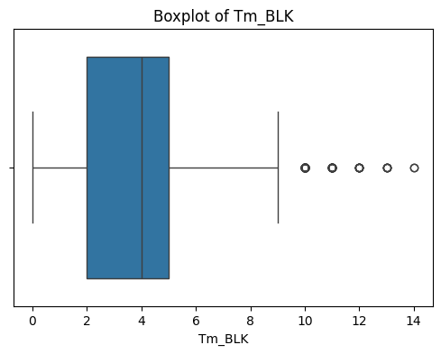

```
Summary statistics for Opp_BLK:
count    4512.000000
mean        3.927305
std         2.257142
min         0.000000
25%         2.000000
50%         4.000000
75%         5.000000
max        14.000000
Name: Opp_BLK, dtype: float64
```

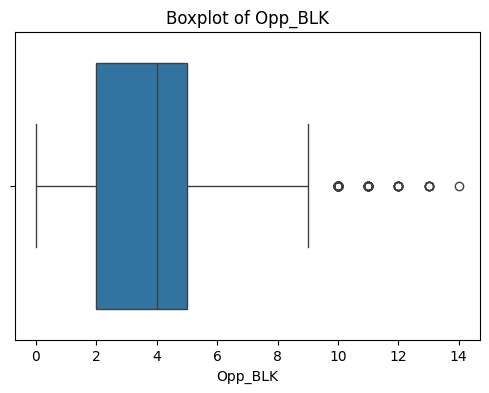

```
Summary statistics for Tm_poss:
count    4512.000000
mean       80.721986
std         5.051364
min        64.080000
25%        77.400000
50%        80.440000
75%        83.720000
max       113.400000
Name: Tm_poss, dtype: float64
```

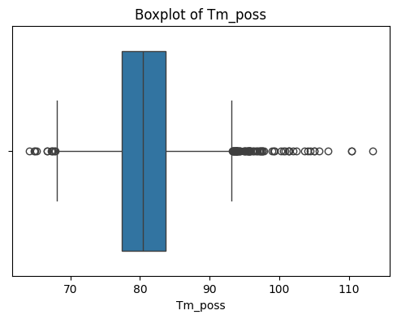

```
Summary statistics for Opp_poss:
count    4512.000000
mean       80.729548
std         5.046140
min        64.080000
25%        77.430000
50%        80.440000
75%        83.720000
max       113.400000
Name: Opp_poss, dtype: float64
```

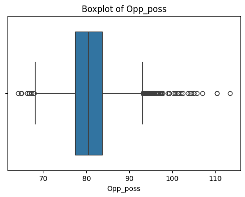

```
Summary statistics for Opp_STL:
count    4512.000000
mean        7.278147
std         2.886531
min         0.000000
25%         5.000000
50%         7.000000
75%         9.000000
max        20.000000
Name: Opp_STL, dtype: float64
```

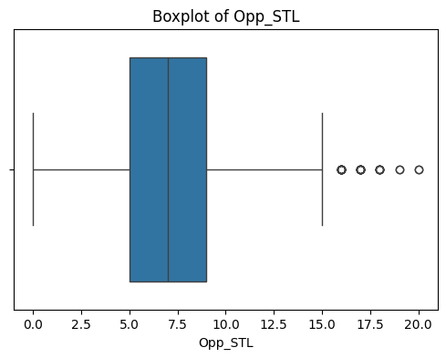

```
Summary statistics for Tm_STL:
count    4512.000000
mean        7.281250
std         2.892675
min         0.000000
25%         5.000000
50%         7.000000
75%         9.000000
max        20.000000
Name: Tm_STL, dtype: float64
```

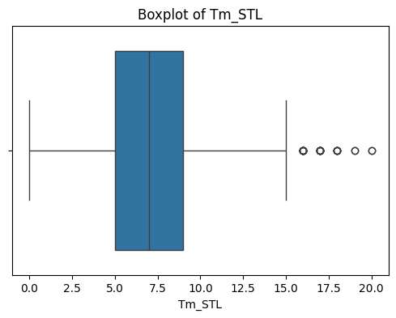

```
Summary statistics for Tm_ORB:
count    4512.000000
mean        8.501773
std         3.451536
min         0.000000
25%         6.000000
50%         8.000000
75%        11.000000
max        23.000000
Name: Tm_ORB, dtype: float64
```

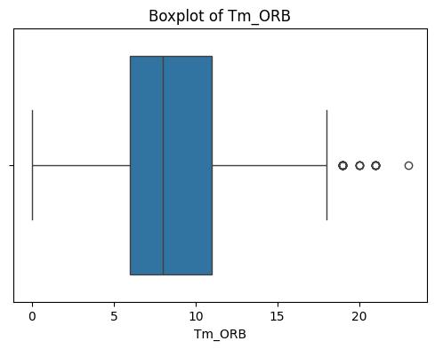

```
Summary statistics for Opp_FGA:
count    4512.000000
mean       67.941933
std         6.374773
min        43.000000
25%        64.000000
50%        68.000000
75%        72.000000
max       100.000000
Name: Opp_FGA, dtype: float64
```

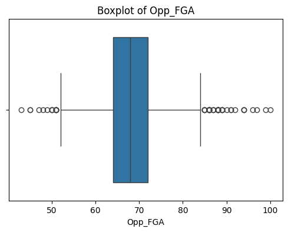

```
Summary statistics for Tm_3P%:
count    4512.000000
mean        0.339195
std         0.110849
min         0.000000
25%         0.267000
50%         0.333000
75%         0.412000
max         0.800000
Name: Tm_3P%, dtype: float64
```

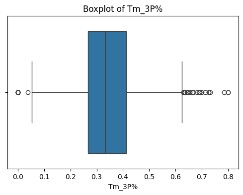

```
Summary statistics for Opp_3P%:
count    4512.000000
mean        0.338616
std         0.111056
min         0.000000
25%         0.267000
50%         0.333000
75%         0.412000
max         0.800000
Name: Opp_3P%, dtype: float64
```

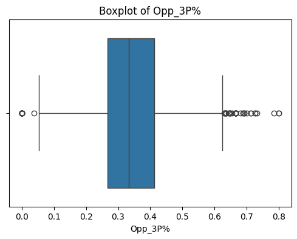

```python
# we plot the summary statistics and box-plot
for col in top10_outliers:
    print(f"\nSummary statistics for {col}:")
    print(df[col].describe())
    plt.figure(figsize=(6, 4))
    sns.boxplot(x=df[col])
    plt.title(f"Boxplot of {col}")
    plt.xlabel(col)
    plt.show()
```

```python
df[df["Tm_BLK"] == 14]
```

|  | Season | Team | Game_Number | Date | Home | Opp | Win_Loss | Tm_Pts | Opp_Pts | Tm_FG | ... | Opp_BLK | Opp_TOV | Opp_PF | win_margin | Tm_poss | Opp_poss | Tm_off_rating | Tm_def_rating | Tm_tov_rate | Opp_tov_rate |
| --- | --- | --- | --- | --- | --- | --- | --- | --- | --- | --- | --- | --- | --- | --- | --- | --- | --- | --- | --- | --- | --- |
| 162 | 2015 | LAS | 27 | 08/23/2015 | 0 | SAS | W | 90 | 59 | 37 | ... | 6 | 10 | 19 | 31 | 78.48 | 79.44 | 114.678899 | 74.269889 | 0.127421 | 0.125881 |
| 1116 | 2018 | ATL | 29 | 08/07/2018 | 1 | LVA | W | 109 | 100 | 43 | ... | 1 | 11 | 17 | 9 | 87.04 | 89.20 | 125.229779 | 112.107623 | 0.091912 | 0.123318 |

2 rows × 48 columns

From the results:

The z score analysis identified several potential outliers. However, after examining the descriptive statistics and considering the context of basketball games, the values likely represent genuine extreme performances rather than data entry errors.

For example: There are two games where Teams' recorded 14 blocks, we can even verify it from the basketball reference site offical box scores, for row 162 (LAS VS SAS on 23/08/2015)-https://www.basketball-reference.com/wnba/boxscores/201508230SAS.html and for row 1116(ATL VS LVA on 08/07/2018) - https://www.basketball-reference.com/wnba/boxscores/201808070ATL.html

Therefore, instead of removing these values, we retain them as valid observations as they capture natural variability in team performance.

**Import Cleaned Dataset**

```python
from google.colab import drive
drive.mount('/content/drive')
```

```python
import pandas as pd

file_path = '/content/drive/MyDrive/wnba_gamelogs_2015_2025_cleaned.csv'
df_cleaned = pd.read_csv(file_path)
```

```python
print("the first 5 entries",df_cleaned.head())
```

```
the first 5 entries    Season Team  Game_Number        Date  Home  Opp Win_Loss  Tm_Pts  Opp_Pts  \
0    2015  ATL            1  06/05/2015     0  NYL        L      73       82
1    2015  ATL            2  06/07/2015     1  CON        L      70       75
2    2015  ATL            3  06/11/2015     1  SAS        W      72       69
3    2015  ATL            4  06/12/2015     0  WAS        W      64       61
4    2015  ATL            5  06/14/2015     0  CON        L      64       82

   Tm_FG  ...  Opp_BLK  Opp_TOV  Opp_PF  win_margin  Tm_poss  Opp_poss  \
0     24  ...        4       15      20          -9    83.68     82.44
1     25  ...        3       11      24          -5    83.92     82.36
2     28  ...        7       17      18           3    78.92     78.92
3     24  ...        2       15      18           3    74.40     72.28
4     26  ...        0       23      16         -18    83.28     78.64

   Tm_off_rating  Tm_def_rating  Tm_tov_rate  Opp_tov_rate
0      87.237094      99.466279     0.227055      0.181951
1      83.412774      91.063623     0.297903      0.133560
2      91.231627      87.430309     0.190066      0.215408
3      86.021505      84.394023     0.215054      0.207526
4      76.849183     104.272635     0.288184      0.292472

[5 rows x 48 columns]
```

```python
print("the last 5 entries",df_cleaned.tail())
```

```
the last 5 entries       Season Team  Game_Number        Date  Home  Opp Win_Loss  Tm_Pts  \
4507    2025  GSV           40  09/02/2025     1  NYL        W      66
4508    2025  GSV           41  09/04/2025     1  DAL        W      84
4509    2025  GSV           42  09/06/2025     1  MIN        L      72
4510    2025  GSV           43  09/09/2025     0  SEA        L      73
4511    2025  GSV           44  09/11/2025     0  MIN        L      53

      Opp_Pts  Tm_FG  ...  Opp_BLK  Opp_TOV  Opp_PF  win_margin  Tm_poss  \
4507       58     22  ...        4       13      18           8    71.80
4508       80     29  ...        5        9      17           4    80.12
4509       78     27  ...        5       10      15          -6    78.28
4510       74     26  ...        7       13      16          -1    70.16
4511       72     19  ...        5       17      12         -19    77.60

      Opp_poss  Tm_off_rating  Tm_def_rating  Tm_tov_rate  Opp_tov_rate
4507     72.36      91.922006      80.154782     0.181058      0.179657
4508     80.80     104.842736      99.009901     0.187219      0.111386
4509     77.04      91.977517     101.246106     0.153296      0.129803
4510     72.80     104.047891     101.648352     0.128278      0.178571
4511     73.96      68.298969      97.349919     0.257732      0.229854

[5 rows x 48 columns]
```

Drive link for cleaned dataset: https://drive.google.com/file/d/1x6AOgmFjTgRzqRaXIIf5saZbTJgM_Ya4/view?usp=sharing

Drive link for uncleaned dataset: https://drive.google.com/file/d/1_Qj-jdKKXUnDKf5r0AR--qlgTlp5VJ2S/view?usp=drive_link

**Project - 3**

**2. Capture initial thoughts:**

I believe that I have the right dataset. My goal is to analyze and predict the key factors that influence winning in a WNBA game. The dataset includes the target variable 'Win_Loss', which supports both prediction and classification problems. It also provides detailed team and opponent statistics (shooting %, rebound and turnovers) that allows for a comprehensive performance analysis

Initial Questions before knowing the data:

1. How is the 2020 WNBA season represented in the dataset, given that it was a shortened season due to COVID-19?
2. Do teams tend to win more because of strong offense or defense?
3. Do home teams have a clear advantage?
4. How are the percentage based statistics represented in the dataset, as proportions (0.45) or percentages (45%)?

**3. Explore Characteristics of the data**

```python
df_cleaned.shape
```

```
(4512, 48)
```

What does each record or row in the dataset represent?

The number of duplicate games is 0, so, each team has one record per game. The number of rows exist per date represents how many team performances were logged that day.

```python
df_cleaned.info()
```

```
<class 'pandas.core.frame.DataFrame'>
RangeIndex: 4512 entries, 0 to 4511
Data columns (total 48 columns):
 #   Column         Non-Null Count  Dtype
---  ------         --------------  -----
 0   Season         4512 non-null   int64
 1   Team           4512 non-null   object
 2   Game_Number    4512 non-null   int64
 3   Date           4512 non-null   object
 4   Home           4512 non-null   int64
 5   Opp            4512 non-null   object
 6   Win_Loss       4512 non-null   object
 7   Tm_Pts         4512 non-null   int64
 8   Opp_Pts        4512 non-null   int64
 9   Tm_FG          4512 non-null   int64
```

[output cut: 40 more lines]

```python
duplicate_rows = df_cleaned[df_cleaned.duplicated()]
print("Number of duplicate rows:", duplicate_rows.shape[0])


duplicate_rows.head()
```

```
Number of duplicate rows: 0
```

|  | Season | Team | Game_Number | Date | Home | Opp | Win_Loss | Tm_Pts | Opp_Pts | Tm_FG | ... | Opp_BLK | Opp_TOV | Opp_PF | win_margin | Tm_poss | Opp_poss | Tm_off_rating | Tm_def_rating | Tm_tov_rate | Opp_tov_rate |
| --- | --- | --- | --- | --- | --- | --- | --- | --- | --- | --- | --- | --- | --- | --- | --- | --- | --- | --- | --- | --- | --- |

0 rows × 48 columns

**4. Additional Transformations:**

i) Convert Win_Loss to numeric : W to 1 and L to 0

ii) Check if percentages are stored correctly

```python
df_cleaned['Win_Loss'] = df_cleaned['Win_Loss'].str.strip().str.upper()
df_cleaned['Win_Loss'] = df_cleaned['Win_Loss'].map({'W': 1, 'L': 0})
df_cleaned['Win_Loss']
```

|  | Win_Loss |
| --- | --- |
| 0 | 0 |
| 1 | 0 |
| 2 | 1 |
| 3 | 1 |
| 4 | 0 |
| ... | ... |
| 4507 | 1 |
| 4508 | 1 |
| 4509 | 0 |
| 4510 | 0 |
| 4511 | 0 |

4512 rows × 1 columns

**dtype:** int64

```python
print(df_cleaned[['Tm_FG%','Tm_3P%','Tm_FT%']].describe())
print(df_cleaned[['Opp_FG%','Opp_3P%','Opp_FT%']].describe())
```

```
            Tm_FG%       Tm_3P%       Tm_FT%
count  4512.000000  4512.000000  4512.000000
mean      0.439962     0.339195     0.796315
std       0.063563     0.110849     0.107565
min       0.234000     0.000000     0.250000
25%       0.397000     0.267000     0.731000
50%       0.439000     0.333000     0.800000
75%       0.484000     0.412000     0.875000
max       0.672000     0.800000     1.000000
           Opp_FG%      Opp_3P%      Opp_FT%
count  4512.000000  4512.000000  4512.000000
mean      0.438661     0.338616     0.796321
std       0.063620     0.111056     0.107566
min       0.234000     0.000000     0.250000
25%       0.394000     0.267000     0.731000
50%       0.438000     0.333000     0.800000
75%       0.483000     0.412000     0.875000
max       0.672000     0.800000     1.000000
```

Since, max < = 1, we can confirm that the columns are in proportions

**5. Explore every variable in the dataset**

i) Datatype:

```python
df_cleaned.dtypes
```

[output not shown]

**dtype:** object

```python
df_cleaned.info()
```

[output not shown]

[output cut: 40 more lines]

ii) Variables and their units:

1. Season - the year in which the game was played
2. Team - Name of the team whose stats are reported
3. G# - game number for that team
4. Date
5. Home - if it is a home game (1) or away game (0) - (binary categorical variable)
6. Opp - Opponent team
7. Win_Loss - Win or Loss

Team performance stats:

1. Tm_pts - points scored by the team, units are measured
2. Tm_FG - Field goals (any shot other than a free throw) made by the team
3. Tm_FGA - Field goals attempted by the team
4. Tm_FG% - Field goal percentage
5. Tm_3P - Three point Field goals made by the team
6. Tm_3PA - Three point Field goals attempted by the team
7. Tm_3PA% - Three point percentage
8. Tm_FT - Free throws made
9. Tm_FTA - Free throws attempted
10. Tm_FT% - Free throw percentage
11. Tm_ORB - Offensive Rebounds
12. Tm_TRB - Total Rebounds
13. Tm_AST - Assists
14. Tm_STL - Steals
15. Tm_BLK - blocks
16. Tm_TOV - turnovers
17. Tm_PF - Personal fouls committed

Opponent Stats:

1. Opp_pts - points scored by the opponent
2. Opp_FG - Field goals (any shot other than a free throw) made by the opponent
3. Opp_FGA - Field goals attempted by the opponent
4. Opp_FG% - Field goal percentage
5. Opp_3P - Three point Field goals made by the opponent
6. Opp_3PA - Three point Field goals attempted by the opponent
7. Opp_3PA% - Three point percentage
8. Opp_FT - Free throws made
9. Opp_FTA - Free throws attempted
10. Opp_FT% - Free throw percentage
11. Opp_ORB - Offensive Rebounds
12. Opp_TRB - Total Rebounds
13. Opp_AST - Assists
14. Opp_STL - Steals
15. Opp_BLK - blocks
16. Opp_TOV - turnovers
17. Opp_PF - Personal fouls committed

Advanced Game Metrics:

1. win_margin - the difference in the points scored (Tm_pts - Opp_pts)
2. Tm_poss - Estimated possessions by the team
3. Opp_poss - Estimated possessions by the opponent
4. Tm_off_rating - offensive rating (points per 100 possession by the team)
5. Tm_def_rating - defensive rating (points allowed per 100 possession by the team)
6. Tm_tov_rate - Team turnover rate (turnovers per possession)
7. Opp_tov_rate - Opponent turnover rate (turnovers per possession)

Shooting percentages - Opp_FG%, Opp_3P%, Opp_FT%, Tm_FG%, Tm_3P%, Tm_FT% Tm_tov_rate, Opp_tov_rate are measured as fractions.

Derived metrics - Tm_off_rating and Tm_def_rating are counts derived from game flow formulas.

Counts - Many variables are simple counts during the game including, (team and opponent)- points, steal, blocks, rebounds, 3P,3PA, free throws, free throw attempts, assists, turnovers, personal fouls.

5. Identifying outliers, missing data, summary statistics, distribution and frequency of the variables values:

The variables are categorized as categorical, numerical and date.

```python
categorical_cols = ['Season','Team','Home','Opp','Win_Loss']
date_cols = ['Date']
numeric_cols = df_cleaned.select_dtypes(include=['int64','float64']).columns.tolist()
numeric_cols = [col for col in df_cleaned.columns if col not in categorical_cols + date_cols]
print("Categorical Columns:", categorical_cols)
print("Date Column:",date_cols)
print("Numeric Columns:",numeric_cols)
```

```
Categorical Columns: ['Season', 'Team', 'Home', 'Opp', 'Win_Loss']
Date Column: ['Date']
Numeric Columns: ['Game_Number', 'Tm_Pts', 'Opp_Pts', 'Tm_FG', 'Tm_FGA', 'Tm_FG%', 'Tm_3P', 'Tm_3PA', 'Tm_3P%', 'Tm_FT', 'Tm_FTA', 'Tm_FT%', 'Tm_ORB', 'Tm_TRB', 'Tm_AST', 'Tm_STL', 'Tm_BLK', 'Tm_TOV', 'Tm_PF', 'Opp_FG', 'Opp_FGA', 'Opp_FG%', 'Opp_3P', 'Opp_3PA', 'Opp_3P%', 'Opp_FT', 'Opp_FTA', 'Opp_…
```

```python
numeric_cols = [col for col in df_cleaned.columns if col not in categorical_cols + date_cols]
df_cleaned[numeric_cols] = df_cleaned[numeric_cols].apply(pd.to_numeric, errors='coerce')
```

From the descriptive statistics below:

ii) Outliers: Tm_pts and Opp_pts have a few high scoring games above the 75th percentile (max = 118). Shooting stats such as Tm_FT and Tm_FGA show extreme values which reflect high scoring and low scoring games. These outliers are reasonable in the context of a basketball game. Unusually high points, field goals, possesions can occur during some matches (as discussed in project-2).

iii) Histograms reveal that most variables have symmetric distribution with moderate spread. Extreme values are also visible but rare, they align with expected basketball performance variance.

```
--- Game_Number ---
Datatype: int64
count    4512.000000
mean       18.423759
std        10.759825
min         1.000000
25%         9.000000
50%        18.000000
75%        27.000000
max        44.000000
Name: Game_Number, dtype: float64
Number of potential outliers: 0
```

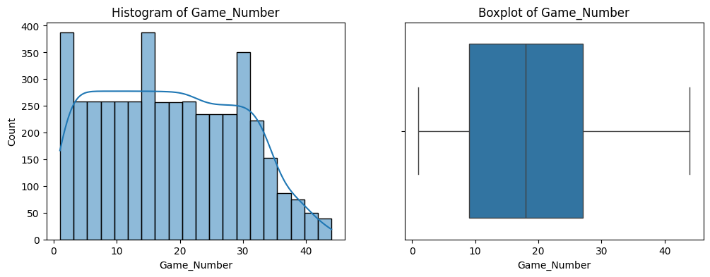

```
--- Tm_Pts ---
Datatype: int64
count    4512.000000
mean       81.346410
std        11.221906
min        45.000000
25%        74.000000
50%        81.000000
75%        89.000000
max       118.000000
Name: Tm_Pts, dtype: float64
Number of potential outliers: 30
```

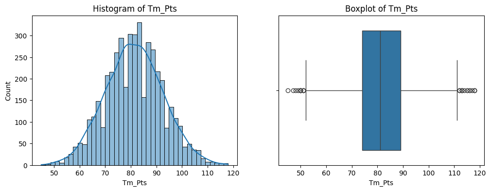

```
--- Opp_Pts ---
Datatype: int64
count    4512.000000
mean       81.171764
std        11.329019
min        45.000000
25%        74.000000
50%        81.000000
75%        89.000000
max       118.000000
Name: Opp_Pts, dtype: float64
Number of potential outliers: 32
```

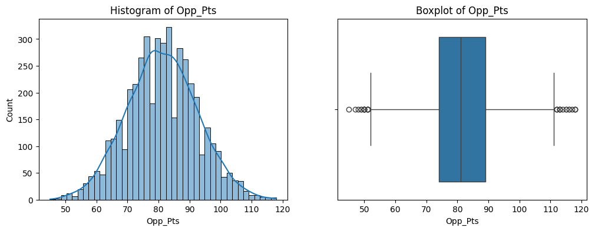

```
--- Tm_FG ---
Datatype: int64
count    4512.000000
mean       29.809397
std         4.658121
min        15.000000
25%        27.000000
50%        30.000000
75%        33.000000
max        46.000000
Name: Tm_FG, dtype: float64
Number of potential outliers: 33
```

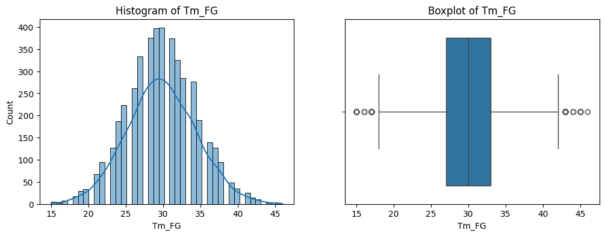

```
--- Tm_FGA ---
Datatype: int64
count    4512.000000
mean       67.927748
std         6.380259
min        43.000000
25%        64.000000
50%        68.000000
75%        72.000000
max       100.000000
Name: Tm_FGA, dtype: float64
Number of potential outliers: 52
```

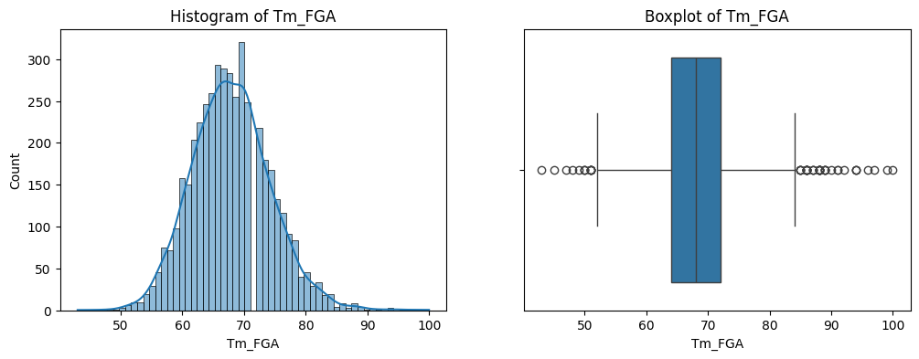

```
--- Tm_FG% ---
Datatype: float64
count    4512.000000
mean        0.439962
std         0.063563
min         0.234000
25%         0.397000
50%         0.439000
75%         0.484000
max         0.672000
Name: Tm_FG%, dtype: float64
Number of potential outliers: 30
```

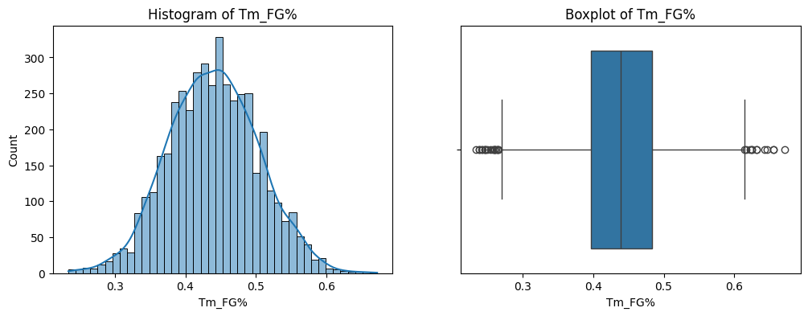

```
--- Tm_3P ---
Datatype: int64
count    4512.000000
mean        6.989805
std         3.107885
min         0.000000
25%         5.000000
50%         7.000000
75%         9.000000
max        22.000000
Name: Tm_3P, dtype: float64
Number of potential outliers: 45
```

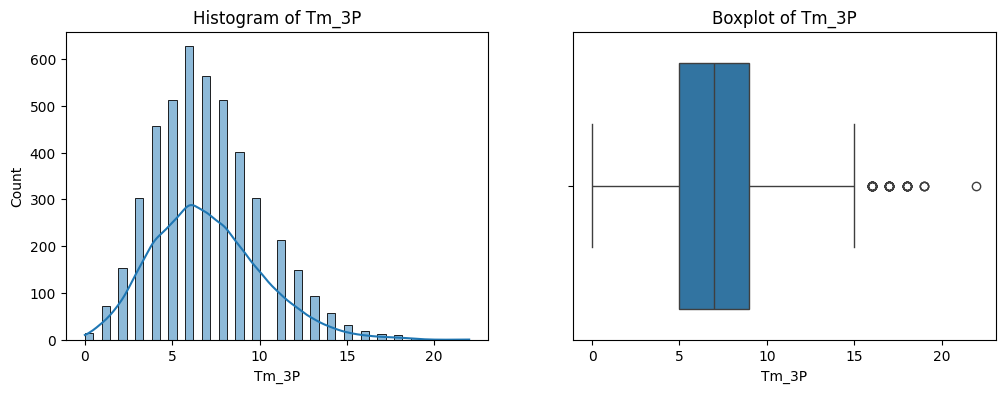

```
--- Tm_3PA ---
Datatype: int64
count    4512.000000
mean       20.506871
std         6.271190
min         3.000000
25%        16.000000
50%        20.000000
75%        25.000000
max        50.000000
Name: Tm_3PA, dtype: float64
Number of potential outliers: 18
```

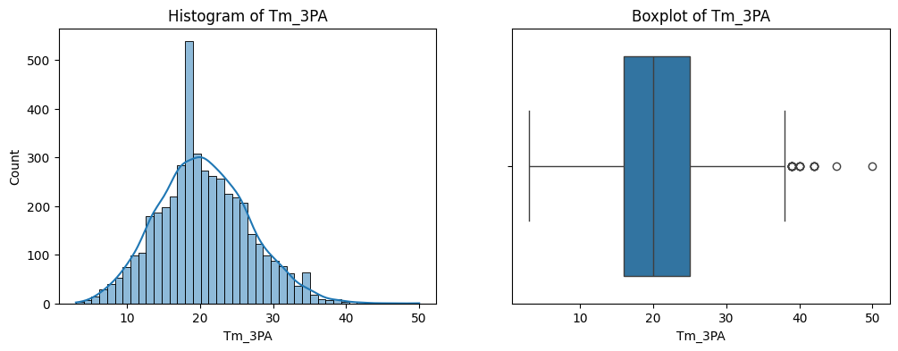

```
--- Tm_3P% ---
Datatype: float64
count    4512.000000
mean        0.339195
std         0.110849
min         0.000000
25%         0.267000
50%         0.333000
75%         0.412000
max         0.800000
Name: Tm_3P%, dtype: float64
Number of potential outliers: 49
```

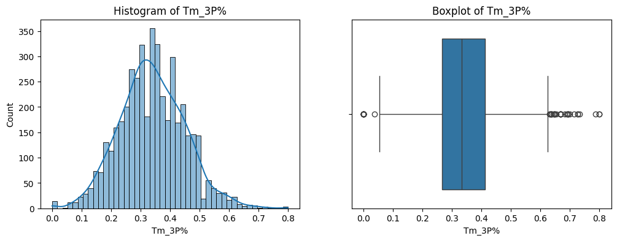

```
--- Tm_FT ---
Datatype: int64
count    4512.000000
mean       14.737367
std         5.649674
min         1.000000
25%        11.000000
50%        14.000000
75%        18.000000
max        41.000000
Name: Tm_FT, dtype: float64
Number of potential outliers: 63
```

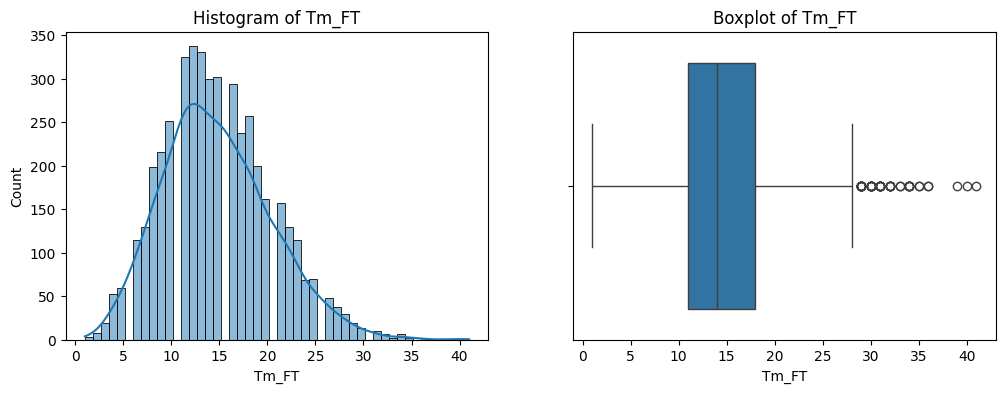

```
--- Tm_FTA ---
Datatype: int64
count    4512.000000
mean       18.515071
std         6.722431
min         1.000000
25%        14.000000
50%        18.000000
75%        23.000000
max        51.000000
Name: Tm_FTA, dtype: float64
Number of potential outliers: 44
```

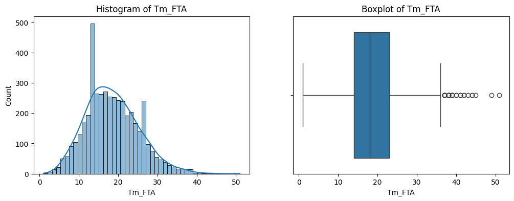

```
--- Tm_FT% ---
Datatype: float64
count    4512.000000
mean        0.796315
std         0.107565
min         0.250000
25%         0.731000
50%         0.800000
75%         0.875000
max         1.000000
Name: Tm_FT%, dtype: float64
Number of potential outliers: 62
```

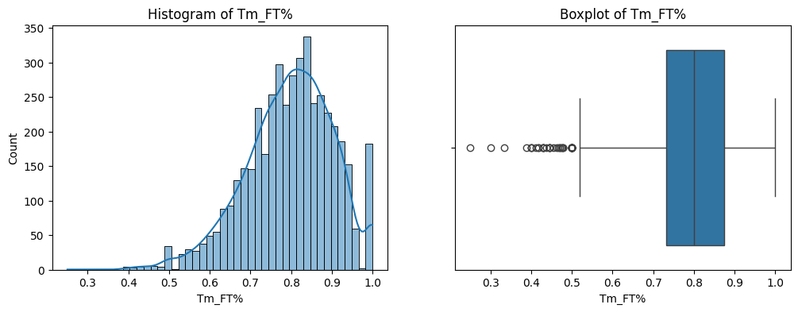

```
--- Tm_ORB ---
Datatype: int64
count    4512.000000
mean        8.501773
std         3.451536
min         0.000000
25%         6.000000
50%         8.000000
75%        11.000000
max        23.000000
Name: Tm_ORB, dtype: float64
Number of potential outliers: 28
```

[30 more figures not shown]

```python
import matplotlib.pyplot as plt
import seaborn as sns
for col in numeric_cols:
    print(f"--- {col} ---")
    print("Datatype:", df_cleaned[col].dtype)
    print(df_cleaned[col].describe())


    Q1 = df_cleaned[col].quantile(0.25)
    Q3 = df_cleaned[col].quantile(0.75)
    IQR = Q3 - Q1
    outliers = df_cleaned[(df_cleaned[col] < Q1 - 1.5*IQR) | (df_cleaned[col] > Q3 + 1.5*IQR)]
    print("Number of potential outliers:", outliers.shape[0])


    plt.figure(figsize=(12,4))
    plt.subplot(1,2,1)
    sns.histplot(df_cleaned[col], kde=True)
    plt.title(f"Histogram of {col}")

    plt.subplot(1,2,2)
    sns.boxplot(x=df_cleaned[col])
    plt.title(f"Boxplot of {col}")

    plt.show()
```

In categorical variables,

Season - Some seasons have more games recorded than others. Eg: 2020 has only 264 games recorded due to COVID-19

Teams - Most teams have 384 games recorded. Newly added teams like GSV have only fewer games recorded

Home - 2256 games at home venue and 2256 games away.

Win_Loss - 2283 Wins and 2229 losses.

Seasons from 2016 - 2019, have many more games than 2020 season which is likely due to COVID 19 bubble season. There is a sharp increase again in the later seasons.

```
--- Season ---
Datatype: int64
Season
2025    572
2023    480
2024    480
2022    432
2019    408
2018    406
2021    382
2016    374
2017    374
2015    340
2020    264
Name: count, dtype: int64
Missing values: 0
```

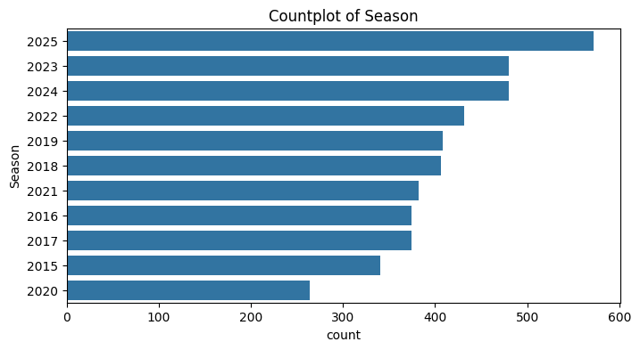

```
--- Team ---
Datatype: object
Team
ATL    384
CHI    384
CON    384
IND    384
LAS    384
NYL    384
PHO    384
SEA    384
MIN    383
WAS    383
DAL    350
LVA    280
GSV     44
Name: count, dtype: int64
Missing values: 0
```

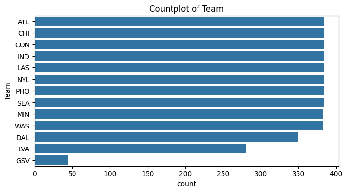

```
--- Home ---
Datatype: int64
Home
0    2256
1    2256
Name: count, dtype: int64
Missing values: 0
```

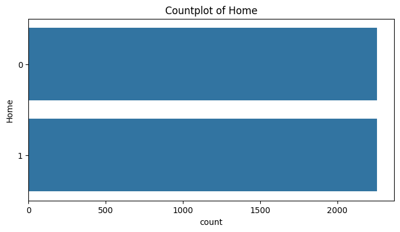

```
--- Opp ---
Datatype: object
Opp
NYL    374
CON    374
IND    374
CHI    374
ATL    374
WAS    373
PHO    369
MIN    369
SEA    368
LAS    367
DAL    344
LVA    280
SAS     98
GSV     44
TUL     30
Name: count, dtype: int64
Missing values: 0
```

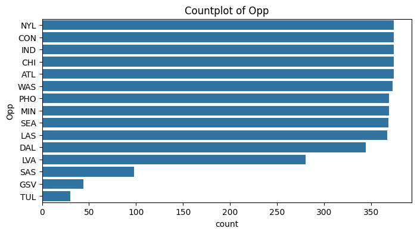

```
--- Win_Loss ---
Datatype: int64
Win_Loss
1    2283
0    2229
Name: count, dtype: int64
Missing values: 0
```

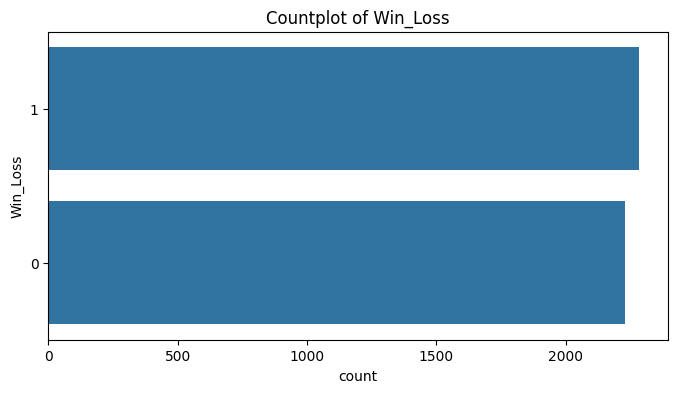

```python
for col in categorical_cols:
    print(f"--- {col} ---")


    print("Datatype:", df_cleaned[col].dtype)


    print(df_cleaned[col].value_counts())


    print("Missing values:", df_cleaned[col].isnull().sum())


    plt.figure(figsize=(8,4))
    sns.countplot(y=df_cleaned[col], order=df_cleaned[col].value_counts().index)
    plt.title(f"Countplot of {col}")
    plt.show()
```

**6. Relationship between variables:**

i) Which ones appear independent? Which ones appear dependent and on what?

Hypothesis - If a team's shooting efficiency (field goal percentage or three point percentage) increases, then the team tends to score more points and win more games.

**Independent variables** - Tm_FG%, Tm_3P%, TmFT%,Tm_off_rating, Tm_def_rating, Tm_TOV, Tm_AST, Tm_STL,Tm_BLK,Tm_PF,Tm_poss,Tm_TOV_rate, Opp_FG%, Opp_3P%, Opp_FT%,Opp_off_rating, Opp_def_rating, Opp_TOV, Opp_AST, Opp_STL,Opp_BLK,Opp_PF,Opp_poss,Opp_TOV_rate

These variables describe how well a team performed during a game. While metrics such as FG% are computed from raw stats (FG = FG/FGA), we treat them as independent variables because better shooting performance or overall performance can lead to higher chance of winning. Opponent columns are not used as primary indicators in our main hypothesis but are included for secondary analysis.

**Dependent variables** - Win_Loss, win_margin

These variables describe the outcome of the game. They are determined after all the actions have occured. For eg: A team's higher FG% and low turnover rate may contribute to a win or higher positive win_margin.

Reference: https://statisticsbyjim.com/regression/independent-dependent-variables/

ii) Explore event frequencies